# Alice Resultados

# Step 5

### Step 5

Step 5: Once we have obtained a model that we feel contains the essential variables, we examine more closely the variables in the model. The question of the appropriate categories for categorical variables should have been addressed during the univariable analysis in Step 1. For each continuous variable in this model we must check the assumption that the logit increases/decreases linearly as a function of the covariate. There are a number of techniques and methods to do this and we discuss them in Section 4.2.1. We refer to the model at the end of Step 5 as the main effects model.

### Passo 5

Etapa 5: Depois de obter um modelo que acreditamos conter o essencial variáveis, examinamos mais de perto as variáveis no modelo. o questão das categorias apropriadas para variáveis categóricas deve foram abordados durante a análise univariável na Etapa 1. Para cada variável contínua neste modelo, devemos verificar a suposição de que o logit aumenta / diminui linearmente em função da covariável. Há um número de técnicas e métodos para fazer isso e os discutiremos na Seção 4.2.1. Nos referimos ao modelo no final da Etapa 5 como o modelo de efeitos principais.

# Step 6

### Step 6

Para esses dados, assumimos que todos os efeitos são aditivos e não tem efeito não linear (sem iteração)

```r
modelo <- glm(X49.bin ~ X10+X11+X12+X2+X3+X31+X4+X5+X6+X7+X8+X9, data = dt, family=binomial)
summary(modelo)
```

```
Call:
glm(formula = X49.bin ~ X10 + X11 + X12 + X2 + X3 + X31 + X4 +
    X5 + X6 + X7 + X8 + X9, family = binomial, data = dt)

Deviance Residuals:
    Min       1Q   Median       3Q      Max
-2.4049  -0.7807   0.2880   0.7535   2.4077

Coefficients:
              Estimate Std. Error z value Pr(>|z|)
(Intercept)   14.12785 1339.63733   0.011 0.991586
X102           0.31585    0.40056   0.789 0.430396
X103           1.39585    0.74464   1.875 0.060858 .
X112          17.92852 1224.07765   0.015 0.988314
X122           0.48744    2.90543   0.168 0.866766
X123           0.15422    0.57770   0.267 0.789507
X124           0.12898    0.86429   0.149 0.881367
X125          -1.97322    1.92144  -1.027 0.304444
X2negra       -1.34063    0.49805  -2.692 0.007108 **
X2parda       -0.86400    0.38785  -2.228 0.025903 *
X32           -0.59975    0.80956  -0.741 0.458794
X33           -0.12166    0.79349  -0.153 0.878143
X34           -0.23737    0.77721  -0.305 0.760054
X35            0.78953    0.98641   0.800 0.423478
X36           -0.17876    1.03521  -0.173 0.862900
X312           0.50982    0.57579   0.885 0.375923
X42            2.21997    0.44174   5.026 5.02e-07 ***
X43            4.07633    1.10359   3.694 0.000221 ***
X52            2.54977    3.00688   0.848 0.396450
X53            2.03011    3.01188   0.674 0.500288
X54            2.24724    3.02154   0.744 0.457033
X55            1.61797    3.04483   0.531 0.595155
X56            3.37390    3.06567   1.101 0.271096
X62           -0.74073    0.85913  -0.862 0.388582
X63           -1.03652    0.81397  -1.273 0.202867
X64           -0.02439    0.82286  -0.030 0.976354
X65           -1.02423    0.93738  -1.093 0.274547
X72           -0.61365    1.07962  -0.568 0.569767
X73           -0.81171    0.94555  -0.858 0.390646
X74           -1.40673    0.97821  -1.438 0.150417
X75           -0.67295    1.11502  -0.604 0.546157
X82           -1.15153    0.47741  -2.412 0.015864 *
X83           -0.37060    0.49273  -0.752 0.451971
X85           -0.35448    0.45248  -0.783 0.433383
X92          -16.25566 1339.63343  -0.012 0.990318
X93          -15.06097 1339.63339  -0.011 0.991030
X94          -15.13383 1339.63335  -0.011 0.990986
X95          -15.57062 1339.63334  -0.012 0.990726
---
Signif. codes:  0 '***' 0.001 '**' 0.01 '*' 0.05 '.' 0.1 ' ' 1

(Dispersion parameter for binomial family taken to be 1)

    Null deviance: 370.33  on 272  degrees of freedom
Residual deviance: 257.42  on 235  degrees of freedom
AIC: 333.42

Number of Fisher Scoring iterations: 15
```

### Step 6

Step 6: Once we have the main effects model, we check for interactions among the variables in the model. In any model, as discussed and illustrated with examples in Section 3.5, an interaction between two variables implies that the effect of each variable is not constant over levels of the other variable. As noted in Section 3.5, the final decision as to whether an interaction term should be included in a model should be based on statistical as well as practical considerations. Any interaction term in the model must make sense from a clinical perspective.

We address the clinical plausibility issue by creating a list of possible pairs of variables in the model that have some realistic possibility of interacting with each other. The interaction variables are created as the arithmetic product of the pairs of main effect variables. This can result in more than one interaction term. For example, the interaction of two categorical variables, each with three levels (i.e., two dummy variables), generates four interaction variables. We add the interactions, one at a time, to the main effects model from Step 5. (This may involve adding more than one term at a time to the model.) We then assess the statistical significance of the interaction using a likelihood ratio test. Unlike main effects where we consider adjustment as well as significance, we only consider the statistical significance of interactions and as such, they must contribute to the model at traditional levels, such as 5% or even 1%. Inclusion of an interaction term in the model that is not significant typically just increases the estimated standard errors without much change in the point estimates of effect.

Following the univariable analysis of the interaction terms we add each interaction that was significant to the model at the end of Step 5. We then follow Step 2 to simplify the model, considering only the removal of the interaction terms, not any main effects. At this point we view the main effect terms as being “locked” and they cannot be removed from the model. One implication of “locking the main effects” is that we do not consider statistical adjustment, $\Delta\hat{\beta}\%$, when winnowing insignificant interactions. We refer to the model at the conclusion of Step 6 as the preliminary final model.

### Passo 6

Etapa 6: Assim que tivermos o modelo de efeitos principais, verificamos as interações entre as variáveis do modelo. Em qualquer modelo, conforme discutido e ilustrado com exemplos na Seção 3.5, uma interação entre duas variáveis implica que o efeito de cada variável não é constante ao longo dos níveis da outra variável. Conforme observado na Seção 3.5, a decisão final sobre se um termo de interação deve ser incluído em um modelo deve ser baseado em estatísticas, bem como considerações práticas. Qualquer termo de interação no modelo deve fazer sentido de uma perspectiva clínica.

Abordamos o problema de plausibilidade clínica criando uma lista de pares possíveis de variáveis no modelo que têm alguma possibilidade realista de interagir um com o outro. As variáveis de interação são criadas como o produto aritmético dos pares de variáveis de efeito principal. Isso pode resultar em mais de um termo de interação. Por exemplo, a interação de duas variáveis categóricas, cada um com três níveis (ou seja, duas variáveis fictícias), gera quatro interações variáveis. Adicionamos as interações, uma de cada vez, ao modelo de efeitos principais da Etapa 5. (Isso pode envolver a adição de mais de um termo por vez ao modelo.) Em seguida, avaliamos a significância estatística da interação usando um teste da razão de verossimilhança. Ao contrário dos efeitos principais, onde consideramos o ajuste como bem como a significância, consideramos apenas a significância estatística das interações e, como tal, devem contribuir para o modelo em níveis tradicionais, como 5% ou mesmo 1%. Inclusão de um termo de interação no modelo que é não significativo, normalmente apenas aumenta os erros padrão estimados sem muita mudança nas estimativas pontuais de efeito.

Seguindo a análise univariável dos termos de interação, adicionamos cada interação que foi significativa para o modelo no final da Etapa 5. Em seguida, siga o Passo 2 para simplificar o modelo, considerando apenas a remoção do termos de interação, não quaisquer efeitos principais. Neste ponto, vemos o efeito principal termos como estando “bloqueados” e não podem ser removidos do modelo. 1 implicação de “bloquear os efeitos principais” é que não consideramos estatísticas ajuste, $\Delta\hat{\beta}\%$, ao separar interações insignificantes. Referimo-nos ao modelo na conclusão da Etapa 6 como a final preliminar modelo.

# Step 7

### Step 7

Código Alice

### Step 7

Step 7: Before any model becomes the final model we must assess its adequacy and check its fit. We discuss these methods in Chapter 5. Note that regardless of what method is used to obtain a multivariable statistical model, purposeful selection or any of the other methods discussed in this chapter, one must perform Step 7 before using the fitted model for inferential purposes.

### Passo 7

Passo 7: Antes de qualquer modelo se tornar o modelo final, devemos avaliar sua adequação e verifique seu ajuste. Discutimos esses métodos no Capítulo 5. Observe que, independentemente de qual método é usado para obter um modelo estatístico multivariável, proposital seleção ou qualquer um dos outros métodos discutidos neste capítulo, deve-se execute a Etapa 7 antes de usar o modelo ajustado para fins inferenciais.

# Stepwise

```r
modeloc <- glm(dt$X49.bin ~ ., data = dt, family=binomial, na.action = "na.fail")
dt <- na.omit(dr)
stepAIC(modeloc, direction="both")
```

```
Start:  AIC=341.09
dt$X49.bin ~ X1 + X3 + X2 + X4 + X5 + X6 + X7 + X8 + X9 + X10 +
    X11 + X12 + X22 + X31 + X32 + X37 + X38

       Df Deviance    AIC
- X12   4   254.45 334.45
- X3    5   257.52 335.52
- X7    4   257.12 337.12
- X5    5   260.34 338.34
- X9    4   258.60 338.60
- X1    1   253.10 339.10
- X38   1   253.10 339.10
- X32   1   253.53 339.53
- X31   1   253.96 339.95
- X37   1   253.97 339.97
- X22   2   256.22 340.22
<none>      253.09 341.09
- X8    3   259.45 341.45
- X10   2   257.60 341.60
- X6    4   261.79 341.79
- X11   1   256.32 342.32
- X2    2   260.80 344.80
- X4    2   287.61 371.61

Step:  AIC=334.45
dt$X49.bin ~ X1 + X3 + X2 + X4 + X5 + X6 + X7 + X8 + X9 + X10 +
    X11 + X22 + X31 + X32 + X37 + X38

       Df Deviance    AIC
- X3    5   258.69 328.69
- X7    4   258.18 330.17
- X5    5   261.70 331.70
- X9    4   260.10 332.10
- X1    1   254.45 332.45
- X38   1   254.48 332.48
- X32   1   254.75 332.75
- X37   1   255.31 333.31
- X31   1   255.44 333.44
- X22   2   257.83 333.83
<none>      254.45 334.45
```

[output cut: 228 more lines]

```
- X6    4   288.31 310.31
+ X37   1   278.42 310.42
- X10   2   284.49 310.49
- X8    3   287.43 311.43
+ X5    5   271.48 311.48
+ X38   1   279.62 311.62
+ X32   1   279.64 311.64
+ X1    1   279.64 311.64
+ X9    4   273.96 311.96
- X2    2   286.80 312.80
+ X22   2   279.02 313.02
+ X3    5   275.07 315.07
+ X7    4   277.62 315.62
+ X12   4   278.36 316.36
- X4    2   319.63 345.63
```

```
Call:  glm(formula = dt$X49.bin ~ X2 + X4 + X6 + X8 + X10 + X11, family = binomial,
    data = dt, na.action = "na.fail")

Coefficients:
(Intercept)      X2negra      X2parda          X42          X43          X62
     0.8087      -1.1319      -0.5183       1.7710       3.3109      -1.3652
        X63          X64          X65          X82          X83          X85
    -1.5085      -0.7207      -1.2743      -1.1198      -0.2772      -0.3603
       X102         X103         X112
     0.3909       1.4170      15.1098

Degrees of Freedom: 272 Total (i.e. Null);  258 Residual
Null Deviance:      370.3
Residual Deviance: 279.6    AIC: 309.6
```

### Modelo

```r
modelo_EBIA_Step <- glm(formula = dt$X49.bin ~ X2 + X4 + X6 + X8 + X11, family = binomial,
    data = dt, na.action = "na.fail")
modelo_EBIA_Step
```

```
Call:  glm(formula = dt$X49.bin ~ X2 + X4 + X6 + X8 + X11, family = binomial,
    data = dt, na.action = "na.fail")

Coefficients:
(Intercept)      X2negra      X2parda          X42          X43          X62
     1.0209      -1.2161      -0.5385       1.8794       3.5148      -1.2356
        X63          X64          X65          X82          X83          X85
    -1.4614      -0.6547      -1.0556      -1.0610      -0.3172      -0.5023
       X112
    15.0670

Degrees of Freedom: 272 Total (i.e. Null);  260 Residual
Null Deviance:      370.3
Residual Deviance: 284.5    AIC: 310.5
```

### Resumo Estatístico

```r
summary(modelo_EBIA_Step)
```

```
Call:
glm(formula = dt$X49.bin ~ X2 + X4 + X6 + X8 + X11, family = binomial,
    data = dt, na.action = "na.fail")

Deviance Residuals:
    Min       1Q   Median       3Q      Max
-2.4607  -0.8768   0.4486   0.7816   2.1299

Coefficients:
            Estimate Std. Error z value Pr(>|z|)
(Intercept)   1.0209     0.6624   1.541  0.12328
X2negra      -1.2161     0.4262  -2.854  0.00432 **
X2parda      -0.5385     0.3291  -1.636  0.10182
X42           1.8794     0.3252   5.779 7.50e-09 ***
X43           3.5148     0.8105   4.337 1.45e-05 ***
X62          -1.2356     0.7075  -1.747  0.08071 .
X63          -1.4614     0.6646  -2.199  0.02787 *
X64          -0.6547     0.6522  -1.004  0.31545
X65          -1.0556     0.8039  -1.313  0.18915
X82          -1.0610     0.4174  -2.542  0.01103 *
X83          -0.3172     0.4428  -0.716  0.47374
X85          -0.5023     0.4016  -1.251  0.21108
X112         15.0670   864.5357   0.017  0.98610
---
Signif. codes:  0 '***' 0.001 '**' 0.01 '*' 0.05 '.' 0.1 ' ' 1

(Dispersion parameter for binomial family taken to be 1)

    Null deviance: 370.33  on 272  degrees of freedom
Residual deviance: 284.49  on 260  degrees of freedom
AIC: 310.49

Number of Fisher Scoring iterations: 14
```

### ANOVA

```r
anova(modelo_EBIA_Step)
```

```
Analysis of Deviance Table

Model: binomial, link: logit

Response: dt$X49.bin

Terms added sequentially (first to last)


     Df Deviance Resid. Df Resid. Dev
NULL                   272     370.33
X2    2   10.233       270     360.09
X4    2   58.034       268     302.06
X6    4    8.485       264     293.57
X8    3    7.051       261     286.52
X11   1    2.031       260     284.49
```

### Análise de resíduos

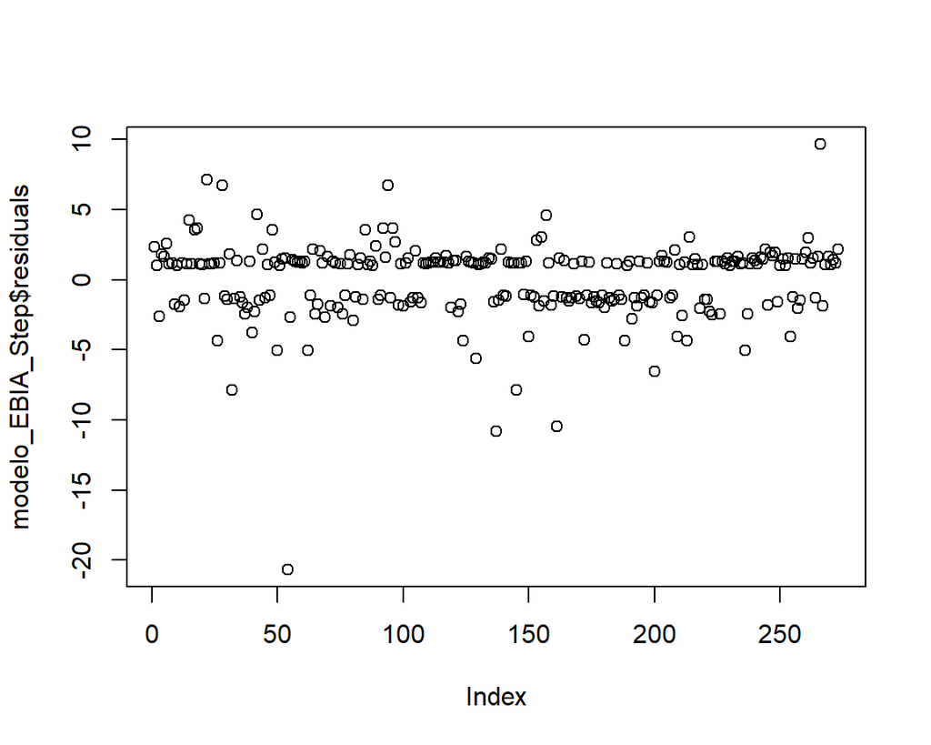

```r
plot(modelo_EBIA_Step$residuals)
```

# PSV

**PSV**

```r
modelo_EBIA_PSV <- glm(X49.bin ~ X10+X11+X12+X2+X3+X31+X4+X5+X6+X7+X8+X9, data = dr, family=binomial)
```

### Resumo Estatístico

```r
summary(modelo_EBIA_PSV)
```

```
Call:
glm(formula = X49.bin ~ X10 + X11 + X12 + X2 + X3 + X31 + X4 +
    X5 + X6 + X7 + X8 + X9, family = binomial, data = dr)

Deviance Residuals:
    Min       1Q   Median       3Q      Max
-2.4049  -0.7807   0.2880   0.7535   2.4077

Coefficients:
              Estimate Std. Error z value Pr(>|z|)
(Intercept)   14.12785 1339.63733   0.011 0.991586
X102           0.31585    0.40056   0.789 0.430396
X103           1.39585    0.74464   1.875 0.060858 .
X112          17.92852 1224.07765   0.015 0.988314
X122           0.48744    2.90543   0.168 0.866766
X123           0.15422    0.57770   0.267 0.789507
X124           0.12898    0.86429   0.149 0.881367
X125          -1.97322    1.92144  -1.027 0.304444
X2negra       -1.34063    0.49805  -2.692 0.007108 **
X2parda       -0.86400    0.38785  -2.228 0.025903 *
X32           -0.59975    0.80956  -0.741 0.458794
X33           -0.12166    0.79349  -0.153 0.878143
X34           -0.23737    0.77721  -0.305 0.760054
X35            0.78953    0.98641   0.800 0.423478
X36           -0.17876    1.03521  -0.173 0.862900
X312           0.50982    0.57579   0.885 0.375923
X42            2.21997    0.44174   5.026 5.02e-07 ***
X43            4.07633    1.10359   3.694 0.000221 ***
X52            2.54977    3.00688   0.848 0.396450
X53            2.03011    3.01188   0.674 0.500288
X54            2.24724    3.02154   0.744 0.457033
X55            1.61797    3.04483   0.531 0.595155
X56            3.37390    3.06567   1.101 0.271096
X62           -0.74073    0.85913  -0.862 0.388582
X63           -1.03652    0.81397  -1.273 0.202867
X64           -0.02439    0.82286  -0.030 0.976354
X65           -1.02423    0.93738  -1.093 0.274547
X72           -0.61365    1.07962  -0.568 0.569767
X73           -0.81171    0.94555  -0.858 0.390646
X74           -1.40673    0.97821  -1.438 0.150417
X75           -0.67295    1.11502  -0.604 0.546157
X82           -1.15153    0.47741  -2.412 0.015864 *
X83           -0.37060    0.49273  -0.752 0.451971
X85           -0.35448    0.45248  -0.783 0.433383
X92          -16.25566 1339.63343  -0.012 0.990318
X93          -15.06097 1339.63339  -0.011 0.991030
X94          -15.13383 1339.63335  -0.011 0.990986
X95          -15.57062 1339.63334  -0.012 0.990726
---
Signif. codes:  0 '***' 0.001 '**' 0.01 '*' 0.05 '.' 0.1 ' ' 1

(Dispersion parameter for binomial family taken to be 1)

    Null deviance: 370.33  on 272  degrees of freedom
Residual deviance: 257.42  on 235  degrees of freedom
AIC: 333.42

Number of Fisher Scoring iterations: 15
```

### ANOVA

```r
anova(modelo_EBIA_PSV)
```

```
Analysis of Deviance Table

Model: binomial, link: logit

Response: X49.bin

Terms added sequentially (first to last)


     Df Deviance Resid. Df Resid. Dev
NULL                   272     370.33
X10   2   22.703       270     347.62
X11   1    2.192       269     345.43
X12   4    5.118       265     340.31
X2    2    6.770       263     333.54
X3    5    4.468       258     329.08
X31   1    3.325       257     325.75
X4    2   36.393       255     289.36
X5    5    6.281       250     283.08
X6    4    8.921       246     274.16
X7    4    4.918       242     269.24
X8    3    6.848       239     262.39
X9    4    4.970       235     257.42
```

### Resíduos

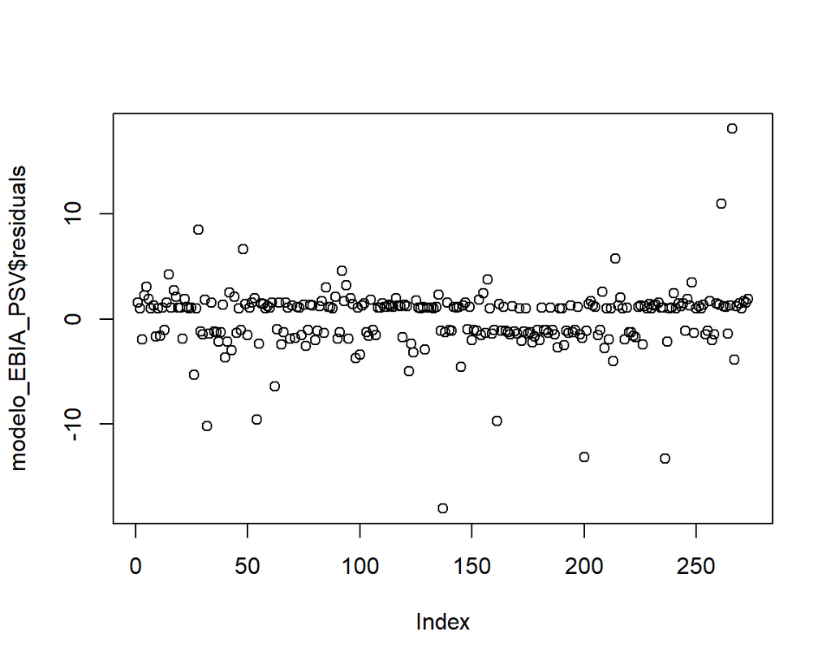

```r
plot(modelo_EBIA_PSV$residuals)
```

# RF

**Random Forest**

Procedimento de seleção de variáveis de três etapas com base em florestas aleatórias para classificação supervisionada e problemas de regressão.

- A primeira etapa (“etapa de limiarização”) é dedicada a eliminar variáveis irrelevantes do conjunto de dados.

florestas aleatórias são calculadas usando a função randomForest com argumentos importância = TRUE, e nossa escolha de valores padrão para ntree e mtry (que são maiores do que o padrão em randomForest para obter mais medida de importância variável estável). Em seguida, as variáveis são classificadas de acordo com sua importância variável média (VI), em ordem decrescente. Essa ordem é mantida ao longo de todo o procedimento. Em seguida, um limite é calculado: min.thres, o valor mínimo previsto de uma árvore CART podada ajustada à curva dos desvios padrão de VI. Finalmente, a “etapa de limiar” real é realizada: apenas as variáveis com um VI médio maior que nmin * min.thres são mantidas.

- A segunda etapa (“etapa de interpretação”) visa selecionar todas as variáveis relacionadas à resposta para efeito de interpretação.

Segunda etapa (“etapa de interpretação”): são consideradas as variáveis selecionadas na primeira etapa. Os modelos de florestas aleatórias incorporados nfor.interp são desenvolvidos, começando com a construção da floresta aleatória apenas com a variável mais importante e terminando com todas as variáveis selecionadas na primeira etapa. Em seguida, err.min, o erro médio out-of-bag (OOB) mínimo desses modelos e seu desvio padrão associado sd.min são calculados. Finalmente, o menor modelo (e, portanto, suas variáveis correspondentes) com um erro OOB médio menor que err.min + nsd * sd.min é selecionado.

Observe que para esta etapa (e a próxima), o parâmetro mtry de randomForest é definido com seu valor padrão (consulte randomForest) se nvm, o número de variáveis no modelo, não for maior que o número de observações, embora seja definido como nvm / 3 caso contrário. Isso é para garantir a qualidade das estimativas de erro OOB ao longo dos modelos de RF incorporados.

A terceira etapa (“etapa de predição”) refina a seleção, eliminando a redundância no conjunto de variáveis selecionadas pela segunda etapa, para efeito de predição.

- Terceira etapa (“etapa de previsão”): o ponto de partida é o mesmo da segunda etapa. No entanto, agora as variáveis são adicionadas ao modelo de maneira gradual. mean.jump, o valor do salto médio é calculado usando variáveis que foram deixadas de fora pela segunda etapa e é definido como a diferença absoluta média entre os erros OOB médios de um modelo e seu primeiro modelo seguinte. Portanto, uma variável é incluída no modelo se a redução média do erro OOB for maior do que nmj * mean.jump.

Quanto à etapa de interpretação, o parâmetro mtry de randomForest é definido com seu valor padrão se nvm, o número de variáveis no modelo, não é maior que o número de observações, enquanto é definido como nvm / 3 caso contrário.

Feito utilizando o pacote `VSURF`, detalhes em https://hal.archives-ouvertes.fr/hal-01251924/

O pacote tem três opções para escolha das variáveis, são elas:

**varselect.thres** Um vetor de índices de variáveis selecionadas após a “etapa de limiarização”, classificadas de acordo com seu VI médio, em ordem decrescente.

**varselect.interp** Um vetor de índices de variáveis selecionadas após a “etapa de interpretação”.

**varselect.pred** Um vetor de índices de variáveis selecionadas após a “etapa de predição”.

Referêncial:

LOUPPE, Gilles et al. Understanding variable importances in forests of randomized trees. Advances in neural information processing systems, v. 26, p. 431-439, 2013.Disponível em: https://proceedings.neurips.cc/paper/2013/file/e3796ae838835da0b6f6ea37bcf8bcb7-Paper.pdf

```r
modelo_EBIA_RF <- VSURF(x = dt[,-18], y = dt$X49.bin, mtry = 200, RFimplem = "randomForest", na.action = na.fail)
```

```
Thresholding step
Estimated computational time (on one core): 122.5 sec.

Interpretation step (on 11 variables)
Estimated computational time (on one core): between 13.7 sec. and  41.3 sec.

Prediction step (on 3 variables)
Maximum estimated computational time (on one core): 4.5 sec.
```

```r
#help(VSURF)
```

### Modelo selecionado por **varselect.thres**

```r
modelo_EBIA_RF$varselect.thres
```

```
 [1]  4  8  6 17  3 10 13  5 14  7  1
```

```r
modelo_EBIA_RForest_VST <- glm(X49.bin ~ X4+X8+X6+X38+X2+X10+X22+X5+X31+X7+X1, data = dt, family = binomial)
```

```r
modelo_EBIA_RForest_VST
```

```
Call:  glm(formula = X49.bin ~ X4 + X8 + X6 + X38 + X2 + X10 + X22 +
    X5 + X31 + X7 + X1, family = binomial, data = dt)

Coefficients:
(Intercept)          X42          X43          X82          X83          X85
   -1.72368      2.11425      3.45604     -1.14245     -0.33309     -0.14863
        X62          X63          X64          X65          X38      X2negra
   -0.97357     -1.16306     -0.20282     -1.26986      0.02308     -1.21669
    X2parda         X102         X103         X224         X225          X52
   -0.64826      0.53334      1.63903      0.66588     -0.18829      1.82097
        X53          X54          X55          X56         X312          X72
    1.04245      1.44354      0.62903      2.59447      0.62702     -0.02163
        X73          X74          X75          X12
   -0.45738     -1.03621     -0.43406      0.01279

Degrees of Freedom: 272 Total (i.e. Null);  245 Residual
Null Deviance:      370.3
Residual Deviance: 267.5    AIC: 323.5
```

### Resumo Estatístico

```r
summary(modelo_EBIA_RForest_VST)
```

```
Call:
glm(formula = X49.bin ~ X4 + X8 + X6 + X38 + X2 + X10 + X22 +
    X5 + X31 + X7 + X1, family = binomial, data = dt)

Deviance Residuals:
    Min       1Q   Median       3Q      Max
-2.4320  -0.7696   0.3542   0.7804   2.4151

Coefficients:
            Estimate Std. Error z value Pr(>|z|)
(Intercept) -1.72368    2.50092  -0.689 0.490686
X42          2.11425    0.40776   5.185 2.16e-07 ***
X43          3.45604    0.90481   3.820 0.000134 ***
X82         -1.14245    0.45960  -2.486 0.012928 *
X83         -0.33309    0.47581  -0.700 0.483894
X85         -0.14863    0.45308  -0.328 0.742881
X62         -0.97357    0.80894  -1.204 0.228778
X63         -1.16306    0.76595  -1.518 0.128901
X64         -0.20282    0.77330  -0.262 0.793110
X65         -1.26986    0.92312  -1.376 0.168941
X38          0.02308    0.12732   0.181 0.856167
X2negra     -1.21669    0.47480  -2.563 0.010392 *
X2parda     -0.64826    0.37303  -1.738 0.082246 .
X102         0.53334    0.35967   1.483 0.138114
X103         1.63903    0.73600   2.227 0.025951 *
X224         0.66588    0.56476   1.179 0.238375
X225        -0.18829    0.91859  -0.205 0.837589
X52          1.82097    2.08074   0.875 0.381491
X53          1.04245    2.07915   0.501 0.616103
X54          1.44354    2.09303   0.690 0.490389
X55          0.62903    2.13621   0.294 0.768407
X56          2.59447    2.16665   1.197 0.231129
X312         0.62702    0.53976   1.162 0.245368
X72         -0.02163    1.01876  -0.021 0.983064
X73         -0.45738    0.86854  -0.527 0.598466
X74         -1.03621    0.89341  -1.160 0.246116
X75         -0.43406    1.02984  -0.421 0.673401
X12          0.01279    0.31844   0.040 0.967972
---
Signif. codes:  0 '***' 0.001 '**' 0.01 '*' 0.05 '.' 0.1 ' ' 1

(Dispersion parameter for binomial family taken to be 1)

    Null deviance: 370.33  on 272  degrees of freedom
Residual deviance: 267.50  on 245  degrees of freedom
AIC: 323.5

Number of Fisher Scoring iterations: 5
```

### ANOVA

```r
anova(modelo_EBIA_RForest_VST)
```

```
Analysis of Deviance Table

Model: binomial, link: logit

Response: X49.bin

Terms added sequentially (first to last)


     Df Deviance Resid. Df Resid. Dev
NULL                   272     370.33
X4    2   57.908       270     312.42
X8    3    6.177       267     306.24
X6    4   11.102       263     295.14
X38   1    0.012       262     295.13
X2    2    8.647       260     286.48
X10   2    4.643       258     281.84
X22   2    0.656       256     281.18
X5    5    9.413       251     271.77
X31   1    0.711       250     271.06
X7    4    3.556       246     267.50
X1    1    0.002       245     267.50
```

### Resíduos

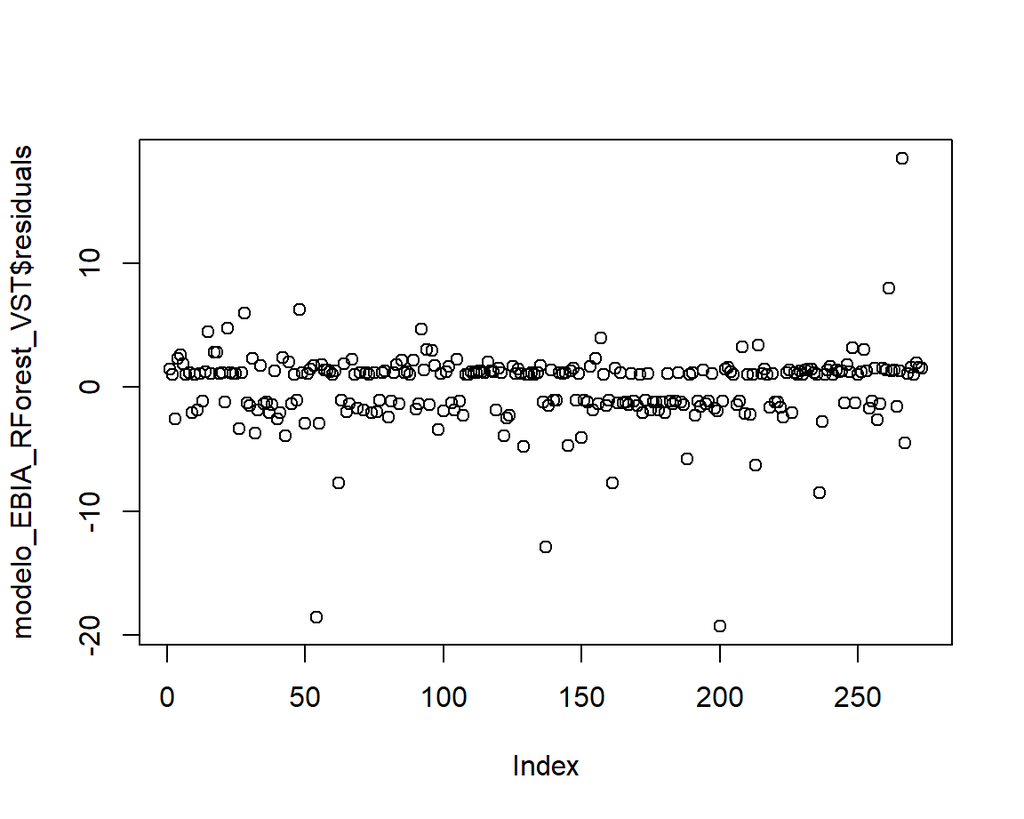

```r
plot(modelo_EBIA_RForest_VST$residuals)
```

### Modelo selecionado por **varselect.interp**

```r
modelo_EBIA_RF$varselect.interp
```

```
[1] 4 8 6
```

```r
modelo_EBIA_RForest_VSI <- glm(X49.bin ~ X4+X8+X6, data = dt, family = binomial)
```

```r
modelo_EBIA_RForest_VSI
```

```
Call:  glm(formula = X49.bin ~ X4 + X8 + X6, family = binomial, data = dt)

Coefficients:
(Intercept)          X42          X43          X82          X83          X85
     0.6000       1.7014       3.5007      -1.0473      -0.3903      -0.4634
        X62          X63          X64          X65
    -1.1947      -1.4741      -0.4958      -0.8086

Degrees of Freedom: 272 Total (i.e. Null);  263 Residual
Null Deviance:      370.3
Residual Deviance: 295.1    AIC: 315.1
```

### Resumo Estatístico

```r
summary(modelo_EBIA_RForest_VSI)
```

```
Call:
glm(formula = X49.bin ~ X4 + X8 + X6, family = binomial, data = dt)

Deviance Residuals:
    Min       1Q   Median       3Q      Max
-2.4026  -0.8110   0.4506   0.8766   1.9073

Coefficients:
            Estimate Std. Error z value Pr(>|z|)
(Intercept)   0.6000     0.6308   0.951   0.3415
X42           1.7014     0.3082   5.520 3.40e-08 ***
X43           3.5007     0.8099   4.322 1.54e-05 ***
X82          -1.0473     0.4129  -2.536   0.0112 *
X83          -0.3903     0.4282  -0.911   0.3621
X85          -0.4634     0.3938  -1.177   0.2392
X62          -1.1947     0.6983  -1.711   0.0871 .
X63          -1.4741     0.6556  -2.249   0.0245 *
X64          -0.4958     0.6426  -0.772   0.4403
X65          -0.8086     0.7798  -1.037   0.2998
---
Signif. codes:  0 '***' 0.001 '**' 0.01 '*' 0.05 '.' 0.1 ' ' 1

(Dispersion parameter for binomial family taken to be 1)

    Null deviance: 370.33  on 272  degrees of freedom
Residual deviance: 295.14  on 263  degrees of freedom
AIC: 315.14

Number of Fisher Scoring iterations: 5
```

### ANOVA

```r
anova(modelo_EBIA_RForest_VSI)
```

```
Analysis of Deviance Table

Model: binomial, link: logit

Response: X49.bin

Terms added sequentially (first to last)


     Df Deviance Resid. Df Resid. Dev
NULL                   272     370.33
X4    2   57.908       270     312.42
X8    3    6.177       267     306.24
X6    4   11.102       263     295.14
```

### Resíduos

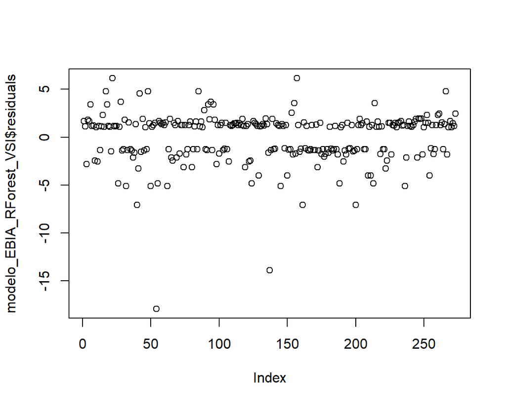

```r
plot(modelo_EBIA_RForest_VSI$residuals)
```

### Modelo selecionado por **varselect.pred**

```r
modelo_EBIA_RF$varselect.pred
```

```
[1] 4
```

```r
modelo_EBIA_RForest_VSP <- glm(X49.bin ~ X4, data = dt, family = binomial)
```

```r
modelo_EBIA_RForest_VSP
```

```
Call:  glm(formula = X49.bin ~ X4, family = binomial, data = dt)

Coefficients:
(Intercept)          X42          X43
    -0.7503       1.6919       3.3153

Degrees of Freedom: 272 Total (i.e. Null);  270 Residual
Null Deviance:      370.3
Residual Deviance: 312.4    AIC: 318.4
```

### Resumo Estatístico

```r
summary(modelo_EBIA_RForest_VSP)
```

```
Call:
glm(formula = X49.bin ~ X4, family = binomial, data = dt)

Deviance Residuals:
    Min       1Q   Median       3Q      Max
-2.2974  -0.8795   0.3850   0.8115   1.5080

Coefficients:
            Estimate Std. Error z value Pr(>|z|)
(Intercept)  -0.7503     0.2081  -3.606 0.000311 ***
X42           1.6919     0.2810   6.022 1.73e-09 ***
X43           3.3153     0.7627   4.347 1.38e-05 ***
---
Signif. codes:  0 '***' 0.001 '**' 0.01 '*' 0.05 '.' 0.1 ' ' 1

(Dispersion parameter for binomial family taken to be 1)

    Null deviance: 370.33  on 272  degrees of freedom
Residual deviance: 312.42  on 270  degrees of freedom
AIC: 318.42

Number of Fisher Scoring iterations: 5
```

### ANOVA

```r
anova(modelo_EBIA_RForest_VSP)
```

```
Analysis of Deviance Table

Model: binomial, link: logit

Response: X49.bin

Terms added sequentially (first to last)


     Df Deviance Resid. Df Resid. Dev
NULL                   272     370.33
X4    2   57.908       270     312.42
```

### Resíduos

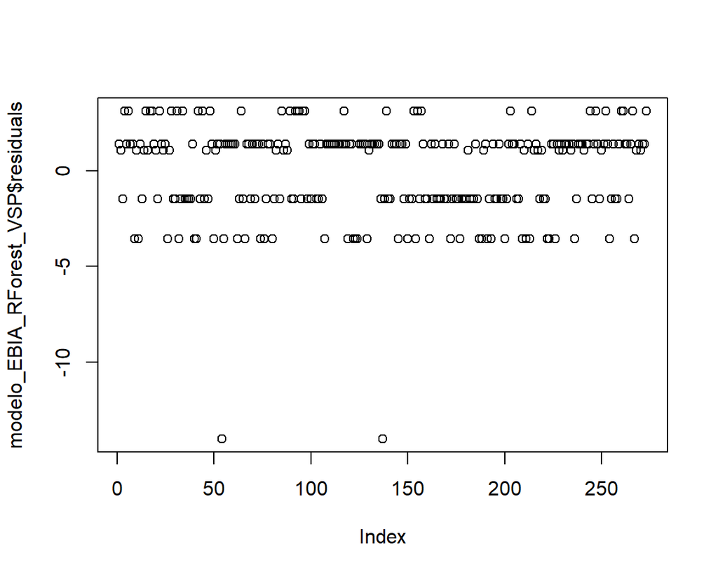

```r
plot(modelo_EBIA_RForest_VSP$residuals)
```

# Lasso

```r
dt <- na.exclude(dd)
x <- model.matrix(~ . - X49.bin, data = dt)[,-1]
y <- cbind(dt$X49.bin)
# Ajuste com penalização lasso
mlasso <- glmnet(x = x, y = y, family = "binomial", alpha = 1, grouped = FALSE)
# Traços
```

```r
# Validação cruzada para escolha do lambda
cv.lasso <- cv.glmnet(x,
                      y,
                      family = "binomial",
                      alpha = 1)
```

```r
cv.lasso$lambda.min
```

```
[1] 0.03065233
```

```r
cv.lasso$lambda.1se
```

```
[1] 0.05878841
```

```r
coef(cv.lasso, s = cv.lasso$lambda.min)
```

```
45 x 1 sparse Matrix of class "dgCMatrix"
                      s1
(Intercept) -0.452964499
X12          .
X32         -0.133422388
X33          .
X34          .
X35          0.028604497
X36          .
X2branca     0.201739711
X2negra     -0.383121656
X2parda      .
X42          1.118250391
X43          1.829583223
X52          0.029661828
X53          .
X54          .
X55         -0.004490061
X56          .
X62          .
X63         -0.276453379
X64          0.227143963
X65          .
X72          .
X73          .
X74          .
X75          0.103074692
X82         -0.225464706
X83          .
X85          .
X92          .
X93          .
X94          .
X95         -0.297473899
X102         .
X103         0.345354237
X112         .
X122         .
X123         .
X124         .
X125         .
X224         .
X225         .
X312         0.199367820
X322         .
X372         .
X38          .
```

**Resultados**

```r
modelo_EBIA_Lasso <- glm(X49.bin ~ X2 + X4 + X6 + X9 + X10, data = dt, family = binomial)

modelo_EBIA_Lasso
```

```
Call:  glm(formula = X49.bin ~ X2 + X4 + X6 + X9 + X10, family = binomial,
    data = dt)

Coefficients:
(Intercept)      X2negra      X2parda          X42          X43          X62
    15.0590      -1.1292      -0.5104       1.6936       3.5516      -1.2589
        X63          X64          X65          X92          X93          X94
    -1.4423      -0.6386      -1.2821     -15.2823     -14.4266     -14.3346
        X95         X102         X103
   -14.9207       0.1495       1.1712

Degrees of Freedom: 272 Total (i.e. Null);  258 Residual
Null Deviance:      370.3
Residual Deviance: 283.6    AIC: 313.6
```

| ### Figura 1 |
| --- |

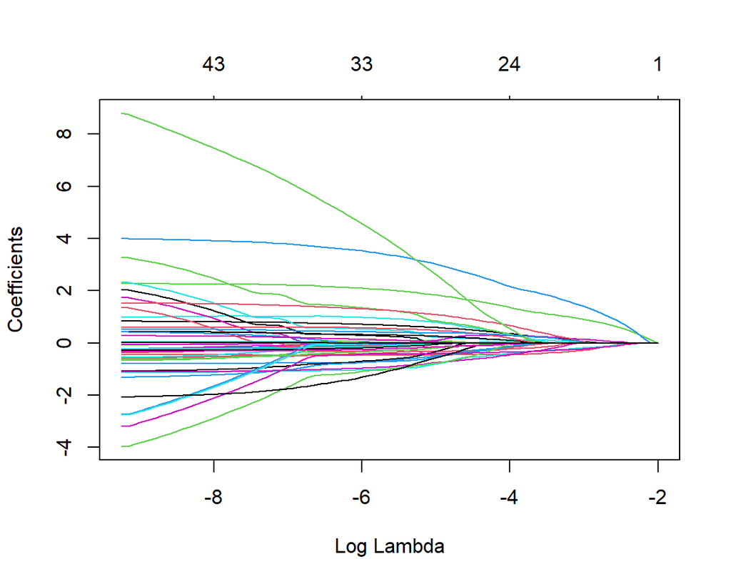

| ### Figura 2 |
| --- |

```r
plot(mlasso, xvar = "lambda")
```

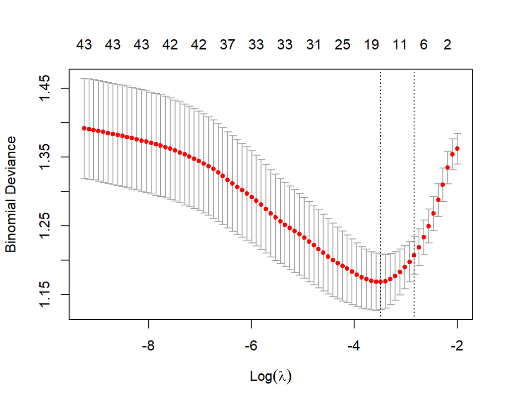

| ### Figura 3 |
| --- |

```r
plot(cv.lasso)
```

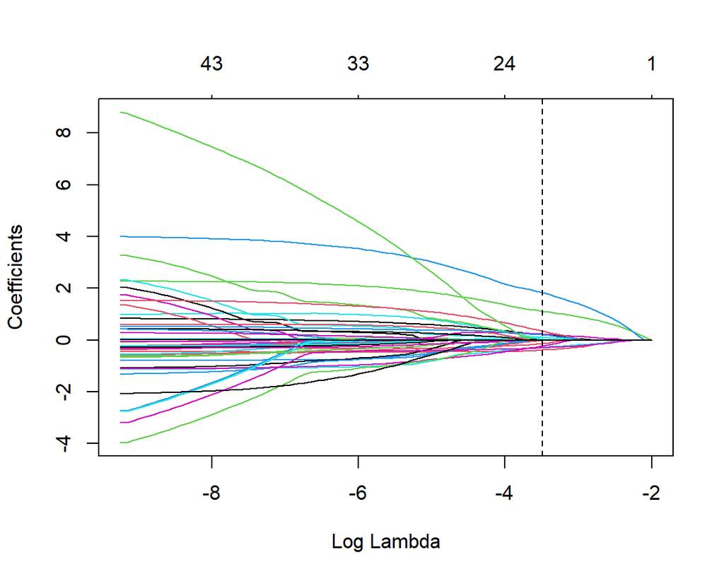

```r
plot(mlasso, xvar = "lambda")
abline(v = log(cv.lasso$lambda.min), lty = 2)
```

### Resumo Estatístico

```r
summary(modelo_EBIA_Lasso)
```

```
Call:
glm(formula = X49.bin ~ X2 + X4 + X6 + X9 + X10, family = binomial,
    data = dt)

Deviance Residuals:
    Min       1Q   Median       3Q      Max
-2.5397  -0.8579   0.4594   0.7979   2.1679

Coefficients:
            Estimate Std. Error z value Pr(>|z|)
(Intercept)  15.0590   838.7437   0.018 0.985675
X2negra      -1.1292     0.4293  -2.630 0.008532 **
X2parda      -0.5104     0.3356  -1.521 0.128372
X42           1.6936     0.3407   4.971 6.65e-07 ***
X43           3.5516     0.9245   3.842 0.000122 ***
X62          -1.2589     0.7214  -1.745 0.080962 .
X63          -1.4423     0.6793  -2.123 0.033728 *
X64          -0.6386     0.6708  -0.952 0.341076
X65          -1.2821     0.8461  -1.515 0.129704
X92         -15.2823   838.7436  -0.018 0.985463
X93         -14.4266   838.7435  -0.017 0.986277
X94         -14.3346   838.7435  -0.017 0.986364
X95         -14.9207   838.7435  -0.018 0.985807
X102          0.1495     0.3372   0.443 0.657455
X103          1.1712     0.6642   1.763 0.077840 .
---
Signif. codes:  0 '***' 0.001 '**' 0.01 '*' 0.05 '.' 0.1 ' ' 1

(Dispersion parameter for binomial family taken to be 1)

    Null deviance: 370.33  on 272  degrees of freedom
Residual deviance: 283.59  on 258  degrees of freedom
AIC: 313.59

Number of Fisher Scoring iterations: 14
```

### ANOVA

```r
anova(modelo_EBIA_Lasso)
```

```
Analysis of Deviance Table

Model: binomial, link: logit

Response: X49.bin

Terms added sequentially (first to last)


     Df Deviance Resid. Df Resid. Dev
NULL                   272     370.33
X2    2   10.233       270     360.09
X4    2   58.034       268     302.06
X6    4    8.485       264     293.57
X9    4    6.512       260     287.06
X10   2    3.473       258     283.59
```

### Resíduos

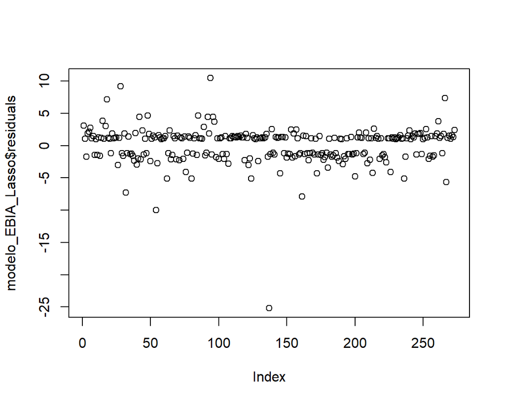

```r
plot(modelo_EBIA_Lasso$residuals)
```

# Comparação

```r
nomes <- c("RForest_VST","RForest_VSI","RForest_VSP","Lasso","Stepwise","PSV")
AIC <- c(summary(modelo_EBIA_RForest_VST)$aic,summary(modelo_EBIA_RForest_VSI)$aic,summary(modelo_EBIA_RForest_VSP)$aic,
         summary(modelo_EBIA_Lasso)$aic,summary(modelo_EBIA_Step)$aic,summary(modelo_EBIA_PSV)$aic)

Residual_Deviance <- c(summary(modelo_EBIA_RForest_VST)$deviance,summary(modelo_EBIA_RForest_VSI)$deviance,summary(modelo_EBIA_RForest_VSP)$deviance,
         summary(modelo_EBIA_Lasso)$deviance,summary(modelo_EBIA_Step)$deviance,summary(modelo_EBIA_PSV)$deviance)

Gl_Residual_Deviance <- c(summary(modelo_EBIA_RForest_VST)$df.residual,summary(modelo_EBIA_RForest_VSI)$df.residual,summary(modelo_EBIA_RForest_VSP)$df.residual,
         summary(modelo_EBIA_Lasso)$df.residual,summary(modelo_EBIA_Step)$df.residual,summary(modelo_EBIA_PSV)$df.residual)

tabela <- cbind(nomes,AIC,Residual_Deviance,Gl_Residual_Deviance)
kable(tabela)
```

| nomes | AIC | Residual_Deviance | Gl_Residual_Deviance |
| --- | --- | --- | --- |
| RForest_VST | 323.498892677739 | 267.498892677739 | 245 |
| RForest_VSI | 315.139466473543 | 295.139466473543 | 263 |
| RForest_VSP | 318.418402824603 | 312.418402824603 | 270 |
| Lasso | 313.589061127316 | 283.589061127316 | 258 |
| Stepwise | 310.492440937655 | 284.492440937655 | 260 |
| PSV | 333.419311216823 | 257.419311216823 | 235 |

[output not shown]

# Carregando dados

```r
setwd("C:/Users/User/Dropbox/Mestrado em Estatística e Experimentação Agropecuária/Dissertaçao/V2")
dados <- read.csv("QFA.csv", sep = ";", header = TRUE)
{
  dados$X1 <- as.factor(dados$X1)
  dados$X2 <- as.factor(dados$X2)
  dados$X3 <- as.factor(dados$X3)
  dados$X4 <- as.factor(dados$X4)
  dados$X5 <- as.factor(dados$X5)
  dados$X6 <- as.factor(dados$X6)
  dados$X7 <- as.factor(dados$X7)
  dados$X8 <- as.factor(dados$X8)
  dados$X9 <- as.factor(dados$X9)
  dados$X10 <- as.factor(dados$X10)
  dados$X11 <- as.factor(dados$X11)
  dados$X12 <- as.factor(dados$X12)
  dados$X22 <- as.factor(dados$X22)
  dados$X31 <- as.factor(dados$X31)
  dados$X32 <- as.factor(dados$X32)
  dados$X33 <- as.factor(dados$X33)
  dados$X37 <- as.factor(dados$X37)
  dados$X38 <- as.numeric(dados$X38)
  dados$X48.2bin <- as.factor(dados$X48.2bin)
}
dd <- dados[,c(1,2,3,4,5,6,7,8,9,10,11,12,22,28,29,30,34,35,45)]
dr <- na.exclude(dd) # retirando os na da variável resposta
summary(dr)
```

```
 X1      X3           X2     X4      X5     X6      X7      X8     X9
 1:120   1: 8   amarela: 0   1: 84   1: 3   1: 11   1:  8   1:58   1:  3
 2:114   2:45   branca :96   2:128   2:72   2: 35   2:  6   2:56   2: 17
         3:69   negra  :42   3: 22   3:89   3: 64   3: 54   3:49   3: 41
         4:84   parda  :96           4:35   4:102   4:133   5:71   4:102
         5:16                        5:18   5: 22   5: 33          5: 71
         6:12                        6:17
 X10     X11     X12     X22     X31     X32     X33    X37          X38
 1: 85   1:233   1:195   1: 20   1: 18   1:149   0:13   1: 92   Min.   :2.000
 2:131   2:  1   2:  2   4:207   2:216   2: 85   1:23   2:142   1st Qu.:4.000
 3: 18           3: 19   5:  7                   2:42           Median :5.000
                 4: 13                           3:82           Mean   :4.983
                 5:  5                           4:51           3rd Qu.:6.000
                                                 5:23           Max.   :9.000
 X48.2bin
 0: 87
 1:147
```

```r
dr <- dr[,-16] # retirando X33
```

# Step 1

### Step 1

Código Alice

Pelo pacote ‘purposeful’

```r
explicativas <- dr[,c(-18)]
explic <- names(explicativas)
# Pelo Pacote
st1 <- purposeful_step_1(data = dr,
                         outcome = "X48.2bin",
                         predictors = explic,
                         # ref_level = "dead",
                         format = TRUE,
                         exponentiate = FALSE)
st1
```

```
# A tibble: 93 x 5
   covariate term  log_odds_ci          p_value below_cutoff
   <chr>     <chr> <chr>                <chr>   <glue>
 1 "X1"      ""    ""                   "0.519" ""
 2 ""        "1"   "Reference level"    ""      ""
 3 ""        "2"   "0.2 (-0.4 to 0.7)"  "0.519" ""
 4 ""        ""    ""                   ""      ""
 5 "X3"      ""    ""                   "0.011" "Less than 0.25"
 6 ""        "1"   "Reference level"    ""      ""
 7 ""        "2"   "0.6 (-1.5 to 2.3)"  "0.517" ""
 8 ""        "3"   "-0.7 (-2.7 to 0.8)" "0.400" ""
 9 ""        "4"   "-0.8 (-2.8 to 0.7)" "0.338" ""
10 ""        "5"   "-1.3 (-3.5 to 0.4)" "0.159" ""
# ... with 83 more rows
```

Selecionando aquelas cujo p-valor <0.25

```r
step1 <- subset(st1, st1$p_value<0.25)
#as variáveis selecionadas foram

vst1 <- step1$covariate
vst1 <- subset(step1$covariate, step1$covariate!="")

explic1 <- vst1
```

As variáveis selecionadas pelo primeiro passo foram:

```r
print(vst1)
```

```
[1] "X3"  "X4"  "X7"  "X8"  "X10" "X12" "X32" "X38"
```

### Step 1

" Step 1: Purposeful selection begins with a careful univariable analysis of each independent variable. For categorical variables we suggest doing this via a standard contingency table analysis of the outcome ($y = 0, 1$) versus the k levels of the independent variable. The usual likelihood ratio chi-square test with $k − 1$ degrees of freedom is exactly equal to the value of the likelihood ratio test for the significance of the coefficients for the k − 1 design variables in a univariable logistic regression model that contains that single independent variable. Since the Pearson chi-square test is asymptotically equivalent to the likelihood ratio chi-square test, it may also be used. In addition to the overall test, it is a good idea, for those variables exhibiting at least a moderate level of association, to estimate the individual odds ratios (along with confidence limits) using one of the levels as the reference group. Particular attention should be paid to any contingency table with a zero (frequency) cell, since in that situation, most standard logistic regression software packages will fail to converge and produce a point estimate for one of the odds ratios of either zero or infinity. An intermediate strategy for dealing with this problem is to collapse categories of the independent variable in some sensible fashion to eliminate the zero cell. If the covariate with the zero cell turns out to be statistically significant, we can revisit the problem at a later stage using one of the special programs discussed in Section 10.3. Fortunately, the zero cell problem does not occur too frequently.

For continuous variables, the best univariable analysis involves fitting a univariable logistic regression model to obtain the estimated coefficient, the estimated standard error, the likelihood ratio test for the significance of the coefficient, and the univariable Wald statistic. An alternative analysis, which is nearly equivalent at the univariable level and that may be preferred in an applied setting, is based on the two-sample t -test. Descriptive statistics available from this analysis generally include group means, standard deviations, the t statistic, and its p-value. The similarity of this approach to the logistic regression analysis follows from the fact that the univariable linear discriminant function estimate of the logistic regression coefficient is

$$\frac{(\bar{x}_1 - \bar{x}_0)}{s_p^2} = \frac{t}{s_p}\sqrt{\frac{1}{n_1}+\frac{1}{n_0}}$$

and that the linear discriminant function and the maximum likelihood estimate of the logistic regression coefficient are usually quite close when the independent variable is approximately normally distributed within each of the outcome groups, y = 0, 1, [see Halpern et al. (1971)]. Thus, the univariable analysis based on the t -test can be used to determine whether the variable should be included in the model since the p-value should be of the same order of magnitude as that of the Wald statistic, Score test, or likelihood ratio test from logistic regression. Through the use of these univariable analyses we identify, as candidates for a first multivariable model, any variable whose univariable test has a p-value less than 0.25 along with all variables of known clinical importance. Our recommendation for using a significance level as high as 0.20 or 0.25 as a screening criterion for initial variable selection is based on the work by Bendel and Afifi (1977) on linear regression and on the work by Mickey and Greenland (1989) on logistic regression. These authors show that use of a more traditional level (such as 0.05) often fails to identify variables known to be important. Use of the higher level has the disadvantage of including variables that are of questionable importance at this initial stage of model development. For this reason, it is important to review all variables added to a model critically before a decision is reached regarding the final model. "

### Passo 1

Etapa 1: a seleção objetiva começa com uma análise cuidadosa e univariável de cada variável independente. Para variáveis categóricas, sugerimos fazer isso por meio de um análise da tabela de contingência padrão do resultado ($y = 0,1$) versus $k$ níveis da variável independente. O teste de qui-quadrado de razão de verossimilhança usual com $k - 1$ graus de liberdade é exatamente igual ao valor da probabilidade teste de razão para a significância dos coeficientes para as variáveis de projeto $k - 1$ em um modelo de regressão logística univariável que contém aquele único variável. Uma vez que o teste do qui-quadrado de Pearson é assintoticamente equivalente ao teste qui-quadrado da razão de verossimilhança, também pode ser usado. Além do geral teste, é uma boa ideia, para aquelas variáveis que exibem pelo menos um nível moderado de associação, para estimar os odds ratios individuais (junto com a confiança limites) usando um dos níveis como o grupo de referência.

Deve-se prestar atenção especial a qualquer tabela de contingência com zero (frequência) célula, uma vez que nessa situação, a maioria da regressão logística padrão pacotes de software não conseguirão convergir e produzir uma estimativa pontual para uma das razões de probabilidade de zero ou infinito. Uma estratégia intermediária para lidar com este problema é reduzir as categorias da variável independente de alguma forma sensata para eliminar a célula zero. Se a covariável com o célula zero acaba sendo estatisticamente significativa, podemos revisitar o problema em um estágio posterior, usando um dos programas especiais discutidos na Seção 10.3. Felizmente, o problema da célula zero não ocorre com muita frequência.

Para variáveis contínuas, a melhor análise univariável envolve o ajuste de um modelo de regressão logística univariável para obter o coeficiente estimado, o erro padrão estimado, o teste da razão de verossimilhança para a significância do coeficiente e estatística univariável de Wald. Uma análise alternativa, que é quase equivalente no nível univariável e que pode ser preferido em uma configuração aplicada é baseada no teste t de duas amostras. Estatísticas descritivas disponíveis a partir desta análise geralmente incluem médias de grupo, desvios-padrão, a estatística t e seu valor p. A semelhança desta abordagem com o a análise de regressão logística segue do fato de que a univariada linear estimativa da função discriminante do coeficiente de regressão logística é

$$\frac{(\bar{x}_1 - \bar{x}_0)}{s_p^2} = \frac{t}{s_p}\sqrt{\frac{1}{n_1}+\frac{1}{n_0}}$$

e que a função discriminante linear e a estimativa de máxima verossimilhança do coeficiente de regressão logística são geralmente muito próximos quando o variável independente é aproximadamente normalmente distribuída dentro de cada um dos grupos de resultados, $y = 0, 1$, [ver Halpern et al. (1971)]. Assim, a univariável análise baseada no teste t pode ser usada para determinar se a variável deve ser incluído no modelo, uma vez que o valor p deve ser o mesmo ordem de magnitude como a da estatística de Wald, teste de pontuação ou razão de verossimilhança teste de regressão logística.

Através do uso dessas análises univariadas, identificamos, como candidatos para um primeiro modelo multivariável, qualquer variável cujo teste univariável tem um Valor de p inferior a 0,25 junto com todas as variáveis de importância clínica conhecida. Nossa recomendação para o uso de um nível de significância tão alto quanto 0,20 ou 0,25 como um critério de triagem para a seleção inicial de variáveis é baseado no trabalho de Bendel e Afifi (1977) na regressão linear e no trabalho de Mickey e Groenlândia (1989) sobre regressão logística. Esses autores mostram que o uso de um nível mais tradicional (como 0,05) muitas vezes falha em identificar variáveis conhecidas ser importante. O uso do nível mais alto tem a desvantagem de incluir variáveis que são de importância questionável neste estágio inicial do modelo desenvolvimento. Por este motivo, é importante revisar todas as variáveis adicionadas ao um modelo criticamente antes de uma decisão sobre o modelo final.

# Step 2

### Step 2

Código Alice

Pelo pacote ‘purposeful’

```r
st2 <- purposeful_step_2(data = dr,
                         outcome = "X48.2bin",
                         predictors = explic1,
                         # ref_level = "dead",
                         format = TRUE,
                         exponentiate = FALSE)
st2
```

```
$covariates_full_model
[1] "X3"  "X4"  "X7"  "X8"  "X10" "X12" "X32" "X38"

$covariates_red_model
[1] "X3"

$results_full_model
# A tibble: 23 x 5
   term        estimate std_error statistic p_value
   <chr>          <dbl>     <dbl>     <dbl>   <dbl>
 1 (Intercept)    0.191     1.32      0.145   0.885
 2 X32            0.447     0.956     0.468   0.640
 3 X33           -0.944     0.889    -1.06    0.288
 4 X34           -0.939     0.884    -1.06    0.288
 5 X35           -1.33      1.01     -1.31    0.189
 6 X36           -1.15      1.06     -1.08    0.279
 7 X42            0.403     0.374     1.08    0.281
 8 X43            0.607     0.677     0.897   0.370
 9 X72           -0.560     1.23     -0.455   0.649
10 X73            0.320     0.869     0.369   0.712
# ... with 13 more rows

$results_red_model
# A tibble: 6 x 5
  term        estimate std_error statistic p_value
  <chr>          <dbl>     <dbl>     <dbl>   <dbl>
1 (Intercept)    1.10      0.816     1.35    0.178
2 X32            0.593     0.914     0.649   0.517
3 X33           -0.717     0.853    -0.841   0.400
4 X34           -0.811     0.846    -0.959   0.338
5 X35           -1.35      0.959    -1.41    0.159
6 X36           -0.762     1.00     -0.759   0.448

$lrt_full_model
# A tibble: 8 x 4
  term  statistic    df p_value
  <chr>     <dbl> <dbl>   <dbl>
1 X3       12.6       5  0.0274
2 X4        1.36      2  0.507
3 X7        1.39      4  0.847
4 X8        4.26      3  0.235
5 X10       4.37      2  0.113
6 X12       2.97      4  0.563
7 X32       0.753     1  0.386
8 X38       2.86      1  0.0908

$lrt_red_model
# A tibble: 1 x 4
  term  statistic    df p_value
  <chr>     <dbl> <dbl>   <dbl>
1 X3         14.8     5  0.0113

$lr_test_results
# A tibble: 2 x 5
  resid_df resid_dev    df deviance p_value
     <dbl>     <dbl> <dbl>    <dbl>   <dbl>
1      211      269.    NA     NA    NA
2      228      294.   -17    -24.7   0.101
```

```r
explic2 <- st2$lrt_red_model$term
```

“O teste da razão de verossimilhança é um teste de hipóteses que compara a qualidade do ajuste de dois modelos, um modelo irrestrito com todos os parâmetros livres, e seu modelo correspondente restrito pela hipótese nula para menos parâmetros, para determinar qual oferece um melhor ajuste para seus dados amostrais.”

Os resultados apontam que o modelo 2 foi melhor do que o 1 contendo apenas as variáveis

```r
st2_2 <- subset(st2$lrt_full_model, st2$lrt_full_model$p_value <0.05)

explic2 <- st2_2$term
explic2
```

```
[1] "X3"
```

### Step 2

" Step 2: Fit the multivariable model containing all covariates identified for inclusion at Step 1. Following the fit of this model, we assess the importance of each covariate using the p-value of its Wald statistic. Variables that do not contribute, at traditional levels of statistical significance, should be eliminated and a new model fit. The new, smaller, model should be compared to the old, larger, model using the partial likelihood ratio test. This is especially important if more than one term has been removed from the model, which is always the case when a categorical variable with more than two levels has been included using two or more design variables that appear to be not significant. Also, one must pay attention to make sure that the samples used to fit the larger and smaller models are the same. This becomes an issue when there are missing data. We discuss strategies for handling missing data in Section 10.4. "

### Passo 2

Ajustar o modelo multivariável contendo todas as covariáveis identificadas para inclusão na Etapa 1. Seguindo o ajuste deste modelo, avaliamos a importância de cada covariável usando o valor p de sua estatística de Wald. Variáveis que não contribuir, em níveis tradicionais de significância estatística, deve ser eliminado e um novo modelo de ajuste. O novo modelo menor deve ser comparado ao antigo, maior, modelo usando o teste de razão de verossimilhança parcial. Isso é especialmente importante se mais de um termo foi removido do modelo, que é sempre o caso quando uma variável categórica com mais de dois níveis foi incluídos usando duas ou mais variáveis de projeto que parecem não ser significativas. Além disso, deve-se prestar atenção para certificar-se de que as amostras utilizadas para ajustar o modelos maiores e menores são iguais. Isso se torna um problema quando há dados ausentes. Discutimos estratégias para lidar com dados ausentes na Seção 10.4.

# Step 3

### Step 3

Código Alice

Pelo pacote ‘purposeful’

```r
st3 <- purposeful_step_3(data = dr,
                         outcome = "X48.2bin",
                         predictors = explic2,
                         # ref_level = "dead",
                         format = TRUE,
                         potential_confounders = explic1) #inserir confundidores
print(st3, n=100)
```

```
# A tibble: 40 x 6
   potential_confounders term  log_odds0 log_odds1 pct_change assessment
   <chr>                 <chr>     <dbl>     <dbl> <chr>      <chr>
 1 X3                    X32       0.593     0.593 0.000%     ""
 2 X3                    X33      -0.717    -0.717 0.000%     ""
 3 X3                    X34      -0.811    -0.811 0.000%     ""
 4 X3                    X35      -1.35     -1.35  0.000%     ""
 5 X3                    X36      -0.762    -0.762 0.000%     ""
 6 X4                    X32       0.593     0.399 -32.770%   "Potential"
 7 X4                    X33      -0.717    -0.928 29.344%    "Potential"
 8 X4                    X34      -0.811    -1.01  24.020%    "Potential"
 9 X4                    X35      -1.35     -1.52  12.458%    ""
10 X4                    X36      -0.762    -0.852 11.778%    ""
11 X7                    X32       0.593     0.591 -0.326%    ""
12 X7                    X33      -0.717    -0.745 3.905%     ""
```

[output cut: 28 more lines]

A variável X3 mudou marcadamente, foram testadas todas as variáveis e identificadas as confundidoras abaixo:

```r
st3$potential_confounders
```

```
 [1] "X3"  "X3"  "X3"  "X3"  "X3"  "X4"  "X4"  "X4"  "X4"  "X4"  "X7"  "X7"
[13] "X7"  "X7"  "X7"  "X8"  "X8"  "X8"  "X8"  "X8"  "X10" "X10" "X10" "X10"
[25] "X10" "X12" "X12" "X12" "X12" "X12" "X32" "X32" "X32" "X32" "X32" "X38"
[37] "X38" "X38" "X38" "X38"
```

```r
explic3 <- c(explic2, levels(factor(st3$potential_confounders)))
explic3
```

```
[1] "X3"  "X10" "X12" "X3"  "X32" "X38" "X4"  "X7"  "X8"
```

Sendo assim as variáveis foram adicionadas ao modelo e refeito os passos 2 e 3

```r
st2.2 <- purposeful_step_2(data = dr,
                         outcome = "X48.2bin",
                         predictors = explic3,
                         # ref_level = "dead",
                         format = TRUE,
                         exponentiate = FALSE)

st3.2 <- purposeful_step_3(data = dr,
                         outcome = "X48.2bin",
                         predictors = explic3,
                         # ref_level = "dead",
                         format = TRUE,
                         potential_confounders = explic1) #inserir confundidores

print(st3.2, n=445)
```

```
# A tibble: 176 x 6
    potential_confounders term  log_odds0 log_odds1 pct_change assessment
    <chr>                 <chr>     <dbl>     <dbl> <chr>      <chr>
  1 X3                    X32      0.447     0.447  0%         ""
  2 X3                    X33     -0.944    -0.944  0%         ""
  3 X3                    X34     -0.939    -0.939  0%         ""
  4 X3                    X35     -1.33     -1.33   0%         ""
  5 X3                    X36     -1.15     -1.15   0%         ""
  6 X3                    X102     0.0880    0.0880 0%         ""
  7 X3                    X103    -1.10     -1.10   0%         ""
  8 X3                    X122    14.7      14.7    0%         ""
  9 X3                    X123     0.107     0.107  0%         ""
 10 X3                    X124     0.0123    0.0123 0%         ""
 11 X3                    X125    -1.29     -1.29   0%         ""
 12 X3                    X322     0.289     0.289  0%         ""
```

[output cut: 164 more lines]

Ao Final do loop dos passos 2 e 3 foram então selecionadas as seguintes variáveis:

```r
explic3
```

```
[1] "X3"  "X10" "X12" "X3"  "X32" "X38" "X4"  "X7"  "X8"
```

### Step 3

Step 3: Following the fit of the smaller, reduced model we compare the values of the estimated coefficients in the smaller model to their respective values from the larger model. In particular, we should be concerned about any variable whose coefficient has changed markedly in magnitude [e.g., having a value of $\Delta \hat{\beta} > 20\%$, see equation (3.9)]. This indicates that one or more of the excluded variables are important in the sense of providing a needed adjustment of the effect of the variables that remained in the model. Such variable(s) should be added back into the model. This process of deleting, refitting, and verifying continues, cycling through Step 2 and Step 3, until it appears that all of the important variables are included in the model and those excluded are clinically and/or statistically unimportant. In this process we recommend that one should proceed slowly by deleting only a few covariates at a time.

### Passo 3

Etapa 3: Seguindo o ajuste do modelo menor e reduzido, comparamos os valores dos coeficientes estimados no modelo menor para seus respectivos valores do modelo maior. Em particular, devemos nos preocupar com qualquer variável cujo coeficiente mudou marcadamente em magnitude [por exemplo, tendo um valor de $\Delta \hat{\beta} > 20\%$, consulte a equação (3.9)]. Isso indica que um ou mais das variáveis excluídas são importantes no sentido de fornecer uma necessária ajuste do efeito das variáveis que permaneceram no modelo. Tal as variáveis devem ser adicionadas de volta ao modelo. Este processo de exclusão, o reaparelhamento e a verificação continuam, passando pelas Etapas 2 e 3, até que parece que todas as variáveis importantes estão incluídas no modelo e aqueles excluídos são clinicamente e / ou estatisticamente sem importância. Neste processo nós recomendo que se proceda lentamente, excluindo apenas algumas covariáveis de uma vez. ————————————-